# Poisson GLMs with R

Count data, rates and overdispersion

O Rodriguez de Rivera Ortega, PhD

University of Exeter

# 1 Session overview

## 1.1 Learning outcomes

By the end of this section, students should be able to:

- identify when a Poisson GLM is appropriate;
- fit a count model using `glm(..., family = poisson)`;
- interpret log-link coefficients as multiplicative effects;
- check for overdispersion using Pearson residuals;
- understand when quasi-Poisson or negative-binomial models may be useful;
- use an offset to model rates when survey effort differs.

## 1.2 Setup

```r
library(tidyverse)
library(MASS)

theme_set(theme_minimal(base_size = 12))
```

# 2 Count data

## 2.1 When do we use a Poisson GLM?

Use a Poisson GLM when the response is a count:

- number of species in a quadrat;
- number of trees in a plot;
- number of disease cases in a region;
- number of defects in a manufacturing process;
- number of ecological events recorded during a survey.

A Poisson random variable has:

$$Y_i \sim \mathrm{Poisson}(\mu_i), \qquad
E(Y_i) = \mu_i, \qquad Var(Y_i) = \mu_i.$$

The usual link is the log link:

$$\log(\mu_i) = \eta_i = \beta_0 + \beta_1
x_{1i} + \cdots + \beta_p x_{pi}.$$

This ensures predicted counts are positive.

## 2.2 Example: warp breaks

The built-in `warpbreaks` dataset records the number of breaks in yarn under different wool types and tension levels.

```r
warp_data <- as_tibble(warpbreaks)

glimpse(warp_data)
```

```
## Rows: 54
## Columns: 3
## $ breaks  <dbl> 26, 30, 54, 25, 70, 52, 51, 26, 67, 18, 21, 29, 17, 12, 18, 35…
## $ wool    <fct> A, A, A, A, A, A, A, A, A, A, A, A, A, A, A, A, A, A, A, A, A,…
## $ tension <fct> L, L, L, L, L, L, L, L, L, M, M, M, M, M, M, M, M, M, H, H, H,…
```

```r
count(warp_data, wool, tension)
```

| wool | tension | n |
| --- | --- | --- |
| A | L | 9 |
| A | M | 9 |
| A | H | 9 |
| B | L | 9 |
| B | M | 9 |
| B | H | 9 |

## 2.3 Explore the counts

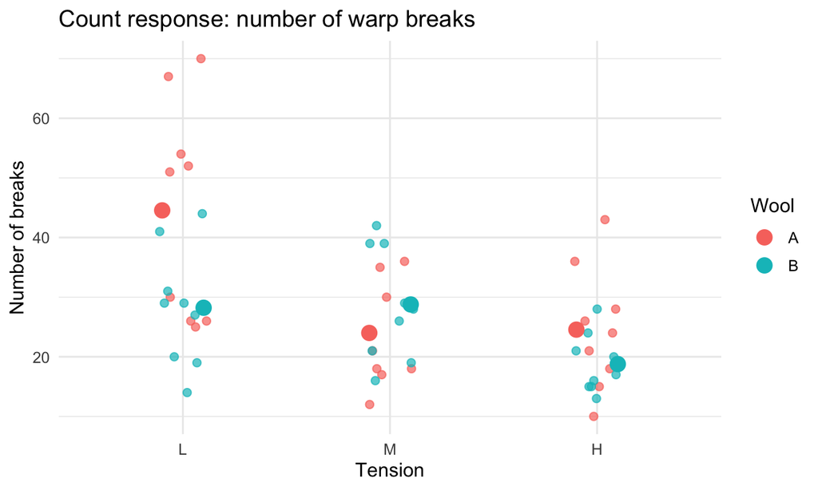

```r
ggplot(warp_data, aes(x = tension, y = breaks, colour = wool)) +
  geom_jitter(width = 0.12, height = 0, alpha = 0.7, size = 2) +
  stat_summary(fun = mean, geom = "point", size = 4,
               position = position_dodge(width = 0.4)) +
  labs(
    title = "Count response: number of warp breaks",
    x = "Tension",
    y = "Number of breaks",
    colour = "Wool"
  )
```

# 3 Fit a Poisson GLM

## 3.1 First model

```r
poisson_mod <- glm(
  breaks ~ wool + tension,
  family = poisson(link = "log"),
  data = warp_data
)

summary(poisson_mod)
```

```
##
## Call:
## glm(formula = breaks ~ wool + tension, family = poisson(link = "log"),
##     data = warp_data)
##
## Coefficients:
##             Estimate Std. Error z value Pr(>|z|)
## (Intercept)  3.69196    0.04541  81.302  < 2e-16 ***
## woolB       -0.20599    0.05157  -3.994 6.49e-05 ***
## tensionM    -0.32132    0.06027  -5.332 9.73e-08 ***
## tensionH    -0.51849    0.06396  -8.107 5.21e-16 ***
## ---
## Signif. codes:  0 '***' 0.001 '**' 0.01 '*' 0.05 '.' 0.1 ' ' 1
##
## (Dispersion parameter for poisson family taken to be 1)
##
##     Null deviance: 297.37  on 53  degrees of freedom
## Residual deviance: 210.39  on 50  degrees of freedom
## AIC: 493.06
##
## Number of Fisher Scoring iterations: 4
```

The coefficients are on the log-count scale.

## 3.2 Rate ratios / count ratios

Exponentiating the coefficients gives multiplicative effects on the expected count.

```r
tibble(
  term = names(coef(poisson_mod)),
  estimate_log_count = coef(poisson_mod),
  multiplicative_effect = exp(coef(poisson_mod))
)
```

| term | estimate_log_count | multiplicative_effect |
| --- | --- | --- |
| (Intercept) | 3.6919631 | 40.1235380 |
| woolB | -0.2059884 | 0.8138425 |
| tensionM | -0.3213204 | 0.7251908 |
| tensionH | -0.5184885 | 0.5954198 |

For example, a multiplicative effect of 0.75 would mean an expected count 25% lower than the reference group, holding other variables constant.

## 3.3 Predicted counts

```r
new_warp <- expand_grid(
  wool = factor(levels(warp_data$wool), levels = levels(warp_data$wool)),
  tension = factor(levels(warp_data$tension), levels = levels(warp_data$tension))
)

pred <- predict(poisson_mod,
                newdata = new_warp,
                type = "link",
                se.fit = TRUE)

new_warp <- new_warp %>%
  mutate(
    fit = exp(pred$fit),
    lower = exp(pred$fit - 1.96 * pred$se.fit),
    upper = exp(pred$fit + 1.96 * pred$se.fit)
  )

new_warp
```

| wool | tension | fit | lower | upper |
| --- | --- | --- | --- | --- |
| A | L | 40.12354 | 36.70666 | 43.85848 |
| A | M | 29.09722 | 26.30932 | 32.18055 |
| A | H | 23.89035 | 21.42064 | 26.64481 |
| B | L | 32.65424 | 29.70341 | 35.89821 |
| B | M | 23.68056 | 21.30320 | 26.32322 |
| B | H | 19.44298 | 17.35122 | 21.78691 |

## 3.4 Plot predicted counts

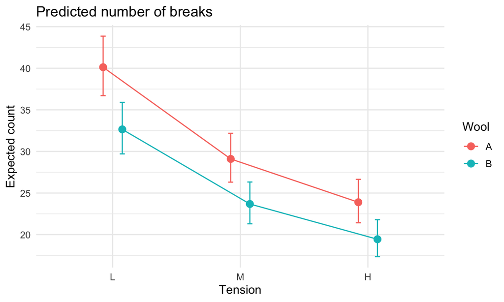

```r
ggplot(new_warp,
       aes(x = tension, y = fit, colour = wool, group = wool)) +
  geom_point(size = 3, position = position_dodge(width = 0.3)) +
  geom_line(position = position_dodge(width = 0.3)) +
  geom_errorbar(aes(ymin = lower, ymax = upper),
                width = 0.08,
                position = position_dodge(width = 0.3)) +
  labs(
    title = "Predicted number of breaks",
    x = "Tension",
    y = "Expected count",
    colour = "Wool"
  )
```

# 4 Model checking

## 4.1 Pearson residuals

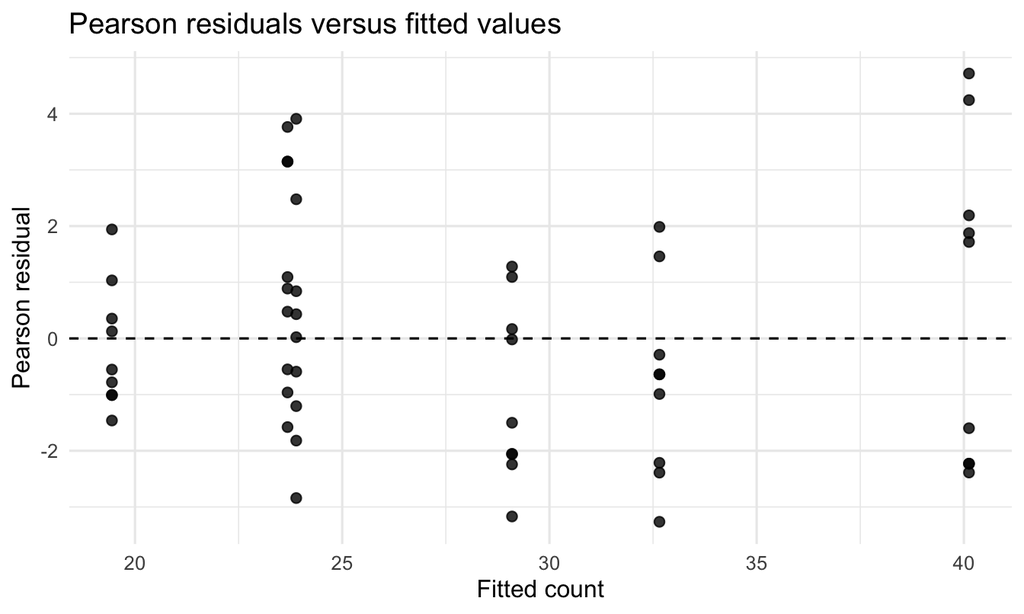

```r
warp_data <- warp_data %>%
  mutate(
    fitted_count = fitted(poisson_mod),
    pearson_resid = residuals(poisson_mod, type = "pearson")
  )

ggplot(warp_data, aes(x = fitted_count, y = pearson_resid)) +
  geom_hline(yintercept = 0, linetype = "dashed") +
  geom_point(size = 2, alpha = 0.8) +
  labs(
    title = "Pearson residuals versus fitted values",
    x = "Fitted count",
    y = "Pearson residual"
  )
```

## 4.2 Overdispersion

For a Poisson GLM, the variance is assumed to equal the mean. Real count data often have larger variance than expected. This is called **overdispersion**.

A simple diagnostic is:

$$\hat{c} = \frac{\sum
r_i^2}{df},$$

where $r_i$ are Pearson residuals.

```r
dispersion_ratio <- function(model) {
  sum(residuals(model, type = "pearson")^2) / df.residual(model)
}

dispersion_ratio(poisson_mod)
```

```
## [1] 4.261522
```

Rules of thumb:

- close to 1: Poisson variance may be adequate;
- clearly above 1: possible overdispersion;
- clearly below 1: possible underdispersion.

## 4.3 Causes of overdispersion

Common causes include:

- missing covariates;
- unmodelled group structure;
- spatial or temporal correlation;
- zero inflation;
- true heterogeneity among observations;
- wrong distributional assumption.

The best response is not automatically to change family. First ask whether the model is missing an important part of the data-generating process.

# 5 Alternative models

## 5.1 Quasi-Poisson

A quasi-Poisson model keeps the same mean structure but estimates an extra dispersion parameter.

```r
quasi_mod <- glm(
  breaks ~ wool + tension,
  family = quasipoisson(link = "log"),
  data = warp_data
)

summary(quasi_mod)
```

```
##
## Call:
## glm(formula = breaks ~ wool + tension, family = quasipoisson(link = "log"),
##     data = warp_data)
##
## Coefficients:
##             Estimate Std. Error t value Pr(>|t|)
## (Intercept)  3.69196    0.09374  39.384  < 2e-16 ***
## woolB       -0.20599    0.10646  -1.935 0.058673 .
## tensionM    -0.32132    0.12441  -2.583 0.012775 *
## tensionH    -0.51849    0.13203  -3.927 0.000264 ***
## ---
## Signif. codes:  0 '***' 0.001 '**' 0.01 '*' 0.05 '.' 0.1 ' ' 1
##
## (Dispersion parameter for quasipoisson family taken to be 4.261537)
##
##     Null deviance: 297.37  on 53  degrees of freedom
## Residual deviance: 210.39  on 50  degrees of freedom
## AIC: NA
##
## Number of Fisher Scoring iterations: 4
```

Quasi-Poisson changes the standard errors, but it does not have a likelihood, so we should not compare it with AIC.

## 5.2 Negative binomial model

A negative-binomial model allows the variance to be larger than the mean.

```r
nb_mod <- glm.nb(breaks ~ wool + tension, data = warp_data)

summary(nb_mod)
```

```
##
## Call:
## glm.nb(formula = breaks ~ wool + tension, data = warp_data, init.theta = 9.944385436,
##     link = log)
##
## Coefficients:
##             Estimate Std. Error z value Pr(>|z|)
## (Intercept)   3.6734     0.0979  37.520  < 2e-16 ***
## woolB        -0.1862     0.1010  -1.844   0.0651 .
## tensionM     -0.2992     0.1217  -2.458   0.0140 *
## tensionH     -0.5114     0.1237  -4.133 3.58e-05 ***
## ---
## Signif. codes:  0 '***' 0.001 '**' 0.01 '*' 0.05 '.' 0.1 ' ' 1
##
## (Dispersion parameter for Negative Binomial(9.9444) family taken to be 1)
##
##     Null deviance: 75.464  on 53  degrees of freedom
## Residual deviance: 53.723  on 50  degrees of freedom
## AIC: 408.76
##
## Number of Fisher Scoring iterations: 1
##
##
##               Theta:  9.94
##           Std. Err.:  2.56
##
##  2 x log-likelihood:  -398.764
```

```r
AIC(poisson_mod, nb_mod)
```

|  | df | AIC |
| --- | --- | --- |
| poisson_mod | 4 | 493.0560 |
| nb_mod | 5 | 408.7638 |

A good workflow is:

1. fit a Poisson model;
2. check residuals and dispersion;
3. think about missing structure;
4. consider quasi-Poisson or negative binomial if overdispersion remains.

## 5.3 Interaction model

We can ask whether the effect of tension differs by wool type.

```r
poisson_interaction <- glm(
  breaks ~ wool * tension,
  family = poisson,
  data = warp_data
)

AIC(poisson_mod, poisson_interaction)
```

|  | df | AIC |
| --- | --- | --- |
| poisson_mod | 4 | 493.0560 |
| poisson_interaction | 6 | 468.9692 |

```r
anova(poisson_mod, poisson_interaction, test = "Chisq")
```

|  | Resid. Df | Resid. Dev | Df | Deviance | Pr(>Chi) |
| --- | --- | --- | --- | --- | --- |
| 1 | 50 | 210.3919 | NA | NA | NA |
| 2 | 48 | 182.3051 | 2 | 28.08676 | 7.962292e-07 |

# 6 Counts versus rates

## 6.1 Why offsets matter

If observations have different sampling effort, raw counts are not directly comparable.

Example: a site surveyed for 4 hours has more opportunity to record events than a site surveyed for 1 hour.

A Poisson model for a rate uses an offset:

$$\log(\mu_i) = \beta_0 + \beta_1 x_i +
\log(\mathrm{effort}_i).$$

Equivalently:

$$\log\left(\frac{\mu_i}{\mathrm{effort}_i}\right)
= \beta_0 + \beta_1 x_i.$$

## 6.2 Simulated ecological survey example

```r
set.seed(123)

survey_counts <- tibble(
  site = 1:80,
  habitat = sample(c("grassland", "woodland"), 80, replace = TRUE),
  effort_hours = runif(80, min = 0.5, max = 4)
) %>%
  mutate(
    true_rate = if_else(habitat == "woodland", 2.2, 1.2),
    expected_count = true_rate * effort_hours,
    count = rpois(n(), lambda = expected_count)
  )

head(survey_counts)
```

| site | habitat | effort_hours | true_rate | expected_count | count |
| --- | --- | --- | --- | --- | --- |
| 1 | grassland | 1.3526682 | 1.2 | 1.623202 | 1 |
| 2 | grassland | 2.8381946 | 1.2 | 3.405833 | 3 |
| 3 | grassland | 1.9617637 | 1.2 | 2.354116 | 3 |
| 4 | woodland | 3.2586854 | 2.2 | 7.169108 | 6 |
| 5 | grassland | 0.8600263 | 1.2 | 1.032032 | 0 |
| 6 | woodland | 2.0221246 | 2.2 | 4.448674 | 4 |

## 6.3 Fit a rate model using an offset

```r
offset_mod <- glm(
  count ~ habitat + offset(log(effort_hours)),
  family = poisson,
  data = survey_counts
)

summary(offset_mod)
```

```
##
## Call:
## glm(formula = count ~ habitat + offset(log(effort_hours)), family = poisson,
##     data = survey_counts)
##
## Coefficients:
##                 Estimate Std. Error z value Pr(>|z|)
## (Intercept)      0.11073    0.09285   1.193    0.233
## habitatwoodland  0.70040    0.12086   5.795 6.84e-09 ***
## ---
## Signif. codes:  0 '***' 0.001 '**' 0.01 '*' 0.05 '.' 0.1 ' ' 1
##
## (Dispersion parameter for poisson family taken to be 1)
##
##     Null deviance: 92.387  on 79  degrees of freedom
## Residual deviance: 58.060  on 78  degrees of freedom
## AIC: 288.98
##
## Number of Fisher Scoring iterations: 4
```

```r
exp(coef(offset_mod))
```

```
##     (Intercept) habitatwoodland
##        1.117088        2.014559
```

The habitat coefficient is interpreted as a multiplicative effect on the expected **rate per hour**, not simply on the raw count.

## 6.4 Visualise counts and effort

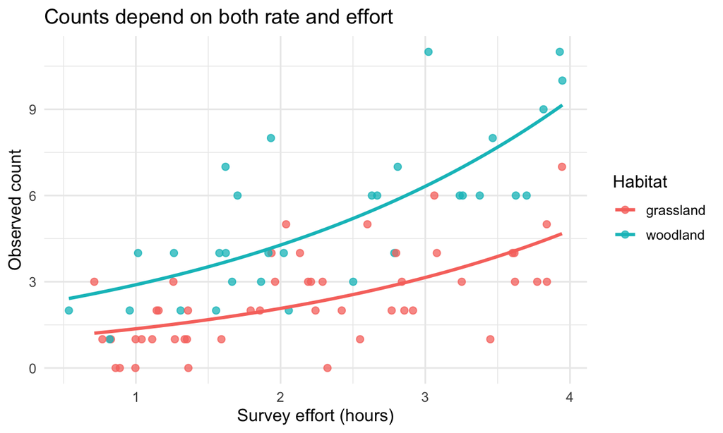

```r
ggplot(survey_counts,
       aes(x = effort_hours, y = count, colour = habitat)) +
  geom_point(size = 2, alpha = 0.75) +
  geom_smooth(method = "glm",
              method.args = list(family = poisson),
              se = FALSE) +
  labs(
    title = "Counts depend on both rate and effort",
    x = "Survey effort (hours)",
    y = "Observed count",
    colour = "Habitat"
  )
```

# 7 Practical exercise

## 7.1 Exercise: extend the count model

Use the `warpbreaks` data.

1. Fit a Poisson model with wool, tension and their interaction.
2. Compare it with the additive model using AIC().
3. Use predict(…, type = “response”) to obtain fitted counts for each wool-by-tension combination.
4. Calculate the dispersion ratio.
5. If there is overdispersion, fit a negative-binomial model using MASS::glm.nb().

## 7.2 Take-home messages

- Poisson GLMs are for counts.
- The log link ensures positive fitted values.
- `exp(coef(model))` gives multiplicative effects.
- Check for overdispersion using Pearson residuals.
- Use offsets when counts come from different amounts of exposure or sampling effort.
- If overdispersion remains, consider quasi-Poisson or negative binomial models.